# Severe Storm Impact on US Economy and Population Health

## Synopsis

This project involves exploring the U.S. National Oceanic and Atmospheric Administration’s (NOAA) storm database. This database tracks characteristics of major storms and weather events in the United States, including when and where they occur, as well as estimates of any fatalities, injuries, and property damage.  
The exploration will endeavor to addresses the following questions:  
1. Across the United States, which types of events are most harmful with respect to population health?  
2. Across the United States, which types of events have the greatest economic consequences?

## Load Packages and set knitr options

First, all packages necessary for the data analysis must be loaded. The three packages listed are used in the following capacities:

- knitR: Used in conjuntion with the R Markdown file to create an HTML file
- dplyr: Used to assist with data manipuation
- ggplot2: Used to create plots

```r
library(knitr)
library(dplyr)
```

```r
library(ggplot2)
```

Also, we set “echo=TRUE” to ensure that all R code is displayed in the assignment and enable caching to speed up development.

```r
require(knitr)
opts_chunk$set(echo = TRUE, cache = TRUE)
```

## Data Processing

First the data must be downloaded into R and made available in a data frame with a little cleanup of dates. This will allow us to filter out events where there is not enough data to draw conclusions (pre-1996), and select only those variables needed for the analysis.  
The following steps are accomplished:

```r
temp <- tempfile()
download.file("https://d396qusza40orc.cloudfront.net/repdata%2Fdata%2FStormData.csv.bz2", method="curl", temp)
data <- tbl_df(read.csv(temp, header = TRUE, sep = ",", quote = "\""))
unlink(temp)
data$BGN_DATE<-as.POSIXct(data$BGN_DATE, tz = "", format = "%m/%d/%Y %H:%M:%S")
# Create health impact data set
data_health <- select(data, EVTYPE, BGN_DATE, FATALITIES, INJURIES)
data_health <- filter(data_health, as.numeric(format(BGN_DATE, "%Y")) > 1995)
data_health$CASUALTIES <- data_health$FATALITIES + data_health$INJURIES
data_health <- filter(data_health, CASUALTIES > 0)
data_health$EVTYPE <- tolower(data_health$EVTYPE)
# Breakdown the data_health into a summary of casualties by event and filter out the events that had no casualties
ev_health <- group_by(data_health, EVTYPE)
ev_health1 <- summarize(ev_health, sum(CASUALTIES))
colnames(ev_health1) <- c("EVTYPE", "CASUALTIES")
# Create economic impact data set
data_econ <- select(data, EVTYPE, BGN_DATE, PROPDMG, PROPDMGEXP, CROPDMG, CROPDMGEXP)
data_econ <- filter(data_econ, as.numeric(format(BGN_DATE, "%Y")) > 1995)
data_econ$EVTYPE <- tolower(data_econ$EVTYPE)
# Normalize the millions and billions and leave out the rest
# Property damage first
data_econ_propm <- filter(data_econ, tolower(PROPDMGEXP) == "m")
data_econ_propm <- select(data_econ_propm, -CROPDMG, -CROPDMGEXP)
data_econ_propm$PROPDMG <- data_econ_propm$PROPDMG * .001
data_econ_propb <- filter(data_econ, tolower(PROPDMGEXP) == "b")
data_econ_propb <- select(data_econ_propb, -CROPDMG, -CROPDMGEXP)
data_econ_prop <- rbind(data_econ_propm, data_econ_propb)
data_econ_prop <- select(data_econ_prop, -BGN_DATE, -PROPDMGEXP)
colnames(data_econ_prop) <- c("EVTYPE", "TTLDMG")

#Crop Damage next

data_econ_cropm <- filter(data_econ, tolower(CROPDMGEXP) == "m")
data_econ_cropm <- select(data_econ_cropm, -PROPDMG, -PROPDMGEXP)
data_econ_cropm$CROPDMG <- data_econ_cropm$CROPDMG * .001
data_econ_cropb <- filter(data_econ, tolower(CROPDMGEXP) == "b")
data_econ_cropb <- select(data_econ_cropb, -PROPDMG, -PROPDMGEXP)
data_econ_crop <- rbind(data_econ_cropm, data_econ_cropb)
data_econ_crop <- select(data_econ_crop, -BGN_DATE, -CROPDMGEXP)
colnames(data_econ_crop) <- c("EVTYPE", "TTLDMG")
ev_econ <- rbind(data_econ_crop, data_econ_prop)
# Breakdown the economic data into a summary of economic cost by event
ev_econ <- group_by(ev_econ, EVTYPE)
ev_econ1 <- summarize(ev_econ, sum(TTLDMG))
colnames(ev_econ1) <- c("EVTYPE", "TTLDMG")
```

## Results

#### Calculating the ten most unhealthy event types across the United States since 1996:

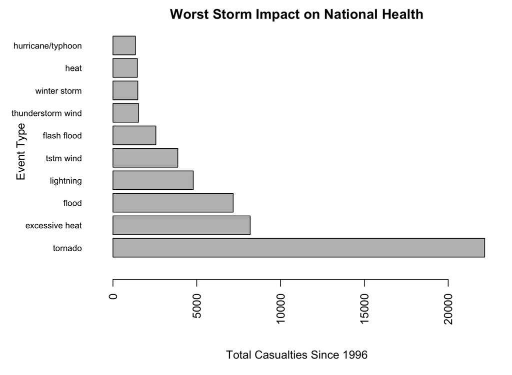

```r
ev_health_worst <- filter(ev_health1, CASUALTIES > 1338)
ev_health_worst <- arrange(ev_health_worst, desc(CASUALTIES))
par(mar = c(8, 8, 2, 2), mgp = c(6,2,1)); barplot(ev_health_worst$CASUALTIES, names.arg = ev_health_worst$EVTYPE, horiz = TRUE, las = 2, cex.names = .75, xlab = "Total Casualties Since 1996", ylab = "Event Type   ", main = "Worst Storm Impact on National Health")
```

#### Calcualting the ten most economically costly event types across the United States since 1996:

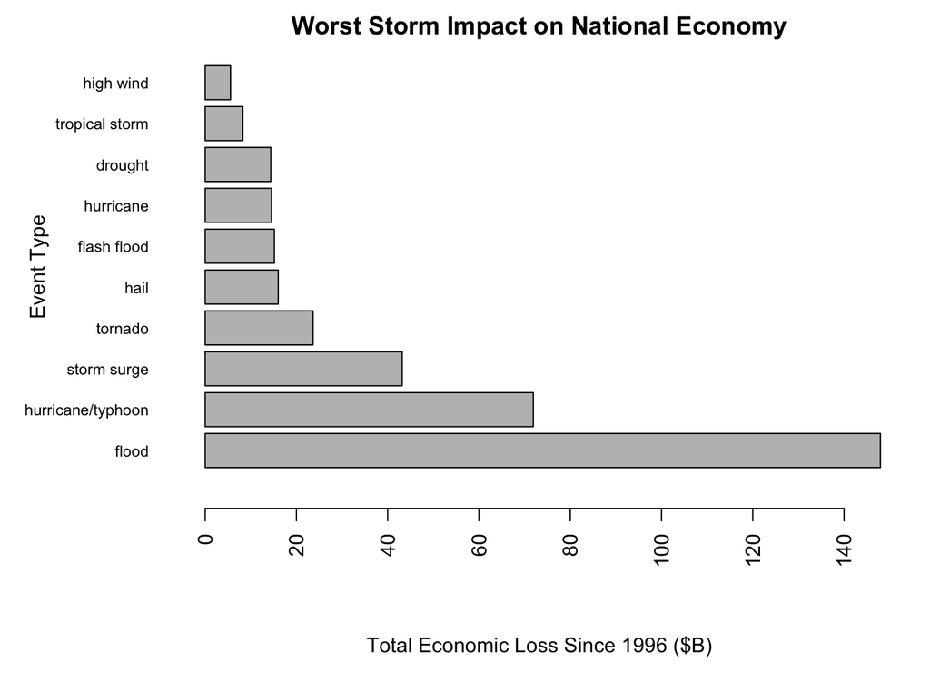

```r
ev_econ_worst <- filter(ev_econ1, TTLDMG > 5.5)
ev_econ_worst <- arrange(ev_econ_worst, desc(TTLDMG))
par(mar = c(8, 8, 2, 2), mgp = c(6,2,1)); barplot(ev_econ_worst$TTLDMG, names.arg = ev_econ_worst$EVTYPE, horiz = TRUE, las = 2, cex.names = .75, xlab = "Total Economic Loss Since 1996 ($B)", ylab = "Event Type", main = "Worst Storm Impact on National Economy")
```